# 0220_meeting

Xinyao Wu

2/20/2020

# Tasks

## 1. Multi-variable propensity score paper

[A Tutorial on Propensity Score Estimation for Multiple Treatments Using Generalized Boosted Models](https://www.ncbi.nlm.nih.gov/pmc/articles/PMC3710547/)

[propensity score review, mentioned multi-exposure](http://citeseerx.ist.psu.edu/viewdoc/download;jsessionid=F25259B79B97955D0C16BD7529683CCE?doi=10.1.1.128.8840&rep=rep1&type=pdf)

[Adaptive contrast weighted learning for multi‐stage multi‐treatment decision‐making](https://onlinelibrary.wiley.com/doi/epdf/10.1111/biom.12539)

## 2. Fill in the blank of last meeting codes

## 3. Sim = 10, plot the bias

## 4. Think carefully the difference of simulation and bootstrap

# Instructions

1. population = 10,000,000, sample(n=825) from pop.
2. Use population to measure true ATE
3. RE-calculate the ATE.(Formula is wrong last week). Use 75th and 25th percentile for each mental.
4. To calculate the estimated ATE in each simulation:  
   *(1) generate data*

```r
#confoundings
age = rnorm(825,22.9,4.2)
iq = rnorm(825,26,5)
edu = rbinom(825,1,0.24)
smoke = rbinom(825,1,0.24)

#exposure

as = age^(1/2)+age*iq+edu+smoke^2+rnorm(825,0,5)
mn = age*2+edu^2+iq+smoke^3+rnorm(825,0,5)
pb = age+iq*edu+iq*smoke+smoke^2+rnorm(825,0,5)

##quantile

quantile(as,probs = c(0.25,0.75))
```

```
##      25%      75%
## 490.0784 695.0198
```

```r
quantile(mn,probs = c(0.25,0.75))
```

```
##      25%      75%
## 64.95152 79.11584
```

```r
quantile(pb,probs = c(0.25,0.75))
```

```
##      25%      75%
## 21.91737 48.38549
```

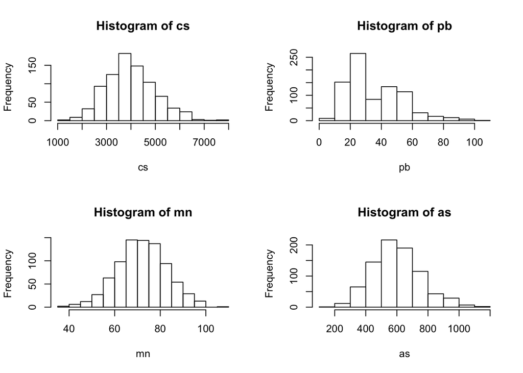

```r
##assume coef
par(mfrow=c(2,2))
cs = 5*as+7*mn-3*pb+age*iq+edu*iq+smoke^2 +rnorm(825,sd = 35)

hist(cs)
hist(pb)
hist(mn)
hist(as)
```

*(1)-2 calculate ATE*

*(2) linear regression*

```r
#propensity score
fit.as = lm(as~age+iq+as.factor(edu)+as.factor(smoke))
fit.mn = lm(mn~age+iq+as.factor(edu)+as.factor(smoke))
fit.pb = lm(pb~age+iq+as.factor(edu)+as.factor(smoke))
summary(fit.as)
```

```
##
## Call:
## lm(formula = as ~ age + iq + as.factor(edu) + as.factor(smoke))
##
## Residuals:
##      Min       1Q   Median       3Q      Max
## -109.913   -8.241   -0.094    8.870  111.723
##
## Coefficients:
##                    Estimate Std. Error  t value Pr(>|t|)
## (Intercept)       -598.8043     5.7812 -103.578   <2e-16 ***
## age                 25.9577     0.1780  145.846   <2e-16 ***
## iq                  23.2224     0.1552  149.615   <2e-16 ***
## as.factor(edu)1      3.4640     1.7482    1.982   0.0479 *
## as.factor(smoke)1    2.2071     1.7300    1.276   0.2024
## ---
## Signif. codes:  0 '***' 0.001 '**' 0.01 '*' 0.05 '.' 0.1 ' ' 1
##
## Residual standard error: 21.44 on 820 degrees of freedom
## Multiple R-squared:  0.9817, Adjusted R-squared:  0.9816
## F-statistic: 1.097e+04 on 4 and 820 DF,  p-value: < 2.2e-16
```

```r
summary(fit.mn)
```

```
##
## Call:
## lm(formula = mn ~ age + iq + as.factor(edu) + as.factor(smoke))
##
## Residuals:
##      Min       1Q   Median       3Q      Max
## -15.0768  -3.4514  -0.0344   3.3541  15.8496
##
## Coefficients:
##                   Estimate Std. Error t value Pr(>|t|)
## (Intercept)        0.59656    1.34222   0.444  0.65683
## age                1.98344    0.04132  48.000  < 2e-16 ***
## iq                 0.98701    0.03604  27.390  < 2e-16 ***
## as.factor(edu)1    1.29549    0.40587   3.192  0.00147 **
## as.factor(smoke)1  0.85099    0.40166   2.119  0.03442 *
## ---
## Signif. codes:  0 '***' 0.001 '**' 0.01 '*' 0.05 '.' 0.1 ' ' 1
##
## Residual standard error: 4.977 on 820 degrees of freedom
## Multiple R-squared:  0.7905, Adjusted R-squared:  0.7895
## F-statistic: 773.5 on 4 and 820 DF,  p-value: < 2.2e-16
```

```r
summary(fit.pb)
```

```
##
## Call:
## lm(formula = pb ~ age + iq + as.factor(edu) + as.factor(smoke))
##
## Residuals:
##      Min       1Q   Median       3Q      Max
## -14.7561  -3.7896  -0.1038   3.6150  18.7303
##
## Coefficients:
##                    Estimate Std. Error t value Pr(>|t|)
## (Intercept)       -12.84414    1.49357   -8.60   <2e-16 ***
## age                 0.97613    0.04598   21.23   <2e-16 ***
## iq                  0.50353    0.04010   12.56   <2e-16 ***
## as.factor(edu)1    25.49633    0.45164   56.45   <2e-16 ***
## as.factor(smoke)1  27.19628    0.44695   60.85   <2e-16 ***
## ---
## Signif. codes:  0 '***' 0.001 '**' 0.01 '*' 0.05 '.' 0.1 ' ' 1
##
## Residual standard error: 5.538 on 820 degrees of freedom
## Multiple R-squared:  0.9037, Adjusted R-squared:  0.9032
## F-statistic:  1924 on 4 and 820 DF,  p-value: < 2.2e-16
```

```r
#Y~AX+C
df = data.frame(cs,as,mn,pb,age,iq,edu,smoke)
fit = lm(cs~as+mn+pb+age+iq+as.factor(edu)+as.factor(smoke),data = df)
summary(fit)
```

```
##
## Call:
## lm(formula = cs ~ as + mn + pb + age + iq + as.factor(edu) +
##     as.factor(smoke), data = df)
##
## Residuals:
##      Min       1Q   Median       3Q      Max
## -105.603  -23.895   -0.219   24.157  111.739
##
## Coefficients:
##                    Estimate Std. Error t value Pr(>|t|)
## (Intercept)       -63.42637   36.11553  -1.756   0.0794 .
## as                  5.90718    0.05782 102.159   <2e-16 ***
## mn                  6.77553    0.24898  27.214   <2e-16 ***
## pb                 -2.62829    0.22377 -11.745   <2e-16 ***
## age                 2.54001    1.63863   1.550   0.1215
## iq                  2.48575    1.40253   1.772   0.0767 .
## as.factor(edu)1    13.68986    6.40906   2.136   0.0330 *
## as.factor(smoke)1  -6.19377    6.73046  -0.920   0.3577
## ---
## Signif. codes:  0 '***' 0.001 '**' 0.01 '*' 0.05 '.' 0.1 ' ' 1
##
## Residual standard error: 35.46 on 817 degrees of freedom
## Multiple R-squared:  0.9988, Adjusted R-squared:  0.9987
## F-statistic: 9.34e+04 on 7 and 817 DF,  p-value: < 2.2e-16
```

*(3) apply coef to generated obs, then calculate the 75th and 25th for each point*

```r
#predict exposures
as.hat = predict(fit.as)
mn.hat = predict(fit.mn)
pb.hat = predict(fit.pb)

quantile(as.hat,c(0.25,0.75))
```

```
##      25%      75%
## 496.6899 702.0925
```

```r
quantile(mn.hat,c(0.25,0.75))
```

```
##      25%      75%
## 65.98681 78.07283
```

```r
quantile(pb.hat,c(0.25,0.75))
```

```
##      25%      75%
## 21.42297 48.59454
```

*(4) estimate Y*

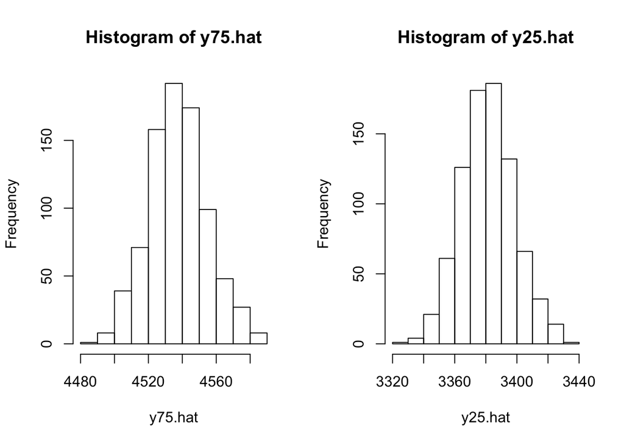

```r
# Y|75% exposure
as = rep(689,825)
mn = rep(78.94541 ,825)
pb = rep(48.83487,825)
new75 = data.frame(as,mn,pb,age,iq,edu,smoke)
y75.hat = predict(fit,new75,type = 'response')

# Y|75% exposure
as = rep(496.6899,825)
mn = rep(65.43030,825)
pb = rep(21.62003,825)
new25 = data.frame(as,mn,pb,age,iq,edu,smoke)
y25.hat = predict.lm(fit,newdata = new25,type = 'response')

par(mfrow = c(1,2))
hist(y75.hat)
hist(y25.hat)
```

*(5) take average*

```r
ATE  = mean(y75.hat)-mean(y25.hat)
print(ATE)
```

```
## [1] 1156.054
```

# review

1. What is the difference of the use of simulation and bootstrap?  
   simulation–point esitimate  
   bootstrap– sd

2.What is the difference of correlated and interacted?  
Y = A+B+B*C  
A = 3B+2  
A and B are correlated. B and C are interacted.